# Assignment Week 11

Sara Leka

2025-05-21

```r
suppressPackageStartupMessages({
  library(epiwraps)
  library(ggplot2)
  library(AnnotationHub)
  library(ensembldb)
  library(edgeR)
  library(rtracklayer)
  library(BiocParallel)
  library(bsseq)   # Class and tools to analyze bisulfite sequencing data at CpG-level
  library(DMRcate) # Identification of differentially-methylated regions
  library(rGREAT)
})

dmrs <- readRDS("dmr.rds")
bs <- readRDS("ESC_astrocytes_BSseq.rds")
```

## 1. Plot a heatmap of the methylation levels of the genes in top 20 (and 5) DMR regions located on chr1

```r
dmrs_chr1 <- dmrs[which(seqnames(dmrs)=="chr1")]
ordered_chr1 <- dmrs_chr1[order(mcols(dmrs_chr1)$meandiff, decreasing = TRUE)]


# Removing CpGs with 0 coverage in some samples
bs <- bs[rowSums(assay(bs,"Cov") > 0) == ncol(bs), ]
bs <- BSmooth(bs, BPPARAM = MulticoreParam(4))

meth_top20 <- getMeth(bs, regions = ordered_chr1[1:20], what = "perRegion")
rownames(meth_top20) <- paste0("DMR_", seq_len(nrow(meth_top20)))
colnames(meth_top20) <- colnames(bs)
meth_top20
```

```
##        astrocytes_ENCFF001TPN astrocytes_ENCFF001TPP ESC_ENCFF001TMC
## DMR_1              0.20672397              0.2679248      0.03761101
## DMR_2              0.60702168              0.7687366      0.08045465
## DMR_3              0.44993283              0.5339064      0.19937389
## DMR_4              0.21914716              0.7643121      0.21546201
## DMR_5              0.41073400              0.6053597      0.10924610
## DMR_6              0.29986661              0.6814079      0.04934198
## DMR_7              0.23816410              0.2356000      0.05768011
## DMR_8              0.22564893              0.2183035      0.19070266
## DMR_9              0.59064643              0.5710820      0.12463150
## DMR_10             0.65690858              0.8134621      0.46051040
## DMR_11             0.15406016              0.4130669      0.03287004
## DMR_12             0.40347955              0.4274178      0.06727169
## DMR_13             0.29208863              0.2513306      0.04469966
## DMR_14             0.04014178              0.3117789      0.15958165
## DMR_15             0.17784809              0.1879880      0.07331578
## DMR_16             0.11169076              0.1679589      0.02443254
## DMR_17             0.19806356              0.4029605      0.20294387
## DMR_18             0.12575487              0.1920507      0.05242420
## DMR_19             0.04112231              0.3233174      0.02744366
## DMR_20             0.20925045              0.3983245      0.13370202
##        ESC_ENCFF001TMD
## DMR_1       0.02804809
## DMR_2       0.07431719
## DMR_3       0.19656007
## DMR_4       0.15315701
## DMR_5       0.08071723
## DMR_6       0.03746201
## DMR_7       0.03971704
## DMR_8       0.18707868
## DMR_9       0.12098850
## DMR_10      0.49266719
## DMR_11      0.03821882
## DMR_12      0.05231159
## DMR_13      0.05618698
## DMR_14      0.04402779
## DMR_15      0.07773589
## DMR_16      0.01774330
## DMR_17      0.20822000
## DMR_18      0.04926579
## DMR_19      0.02905001
## DMR_20      0.15350127
```

```r
meth_top5 <- getMeth(bs, regions = ordered_chr1[1:5], what = "perRegion")
rownames(meth_top5) <- paste0("DMR_", seq_len(nrow(meth_top5)))
colnames(meth_top5) <- colnames(bs)
meth_top5
```

```
##       astrocytes_ENCFF001TPN astrocytes_ENCFF001TPP ESC_ENCFF001TMC
## DMR_1              0.2067240              0.2679248      0.03761101
## DMR_2              0.6070217              0.7687366      0.08045465
## DMR_3              0.4499328              0.5339064      0.19937389
## DMR_4              0.2191472              0.7643121      0.21546201
## DMR_5              0.4107340              0.6053597      0.10924610
##       ESC_ENCFF001TMD
## DMR_1      0.02804809
## DMR_2      0.07431719
## DMR_3      0.19656007
## DMR_4      0.15315701
## DMR_5      0.08071723
```

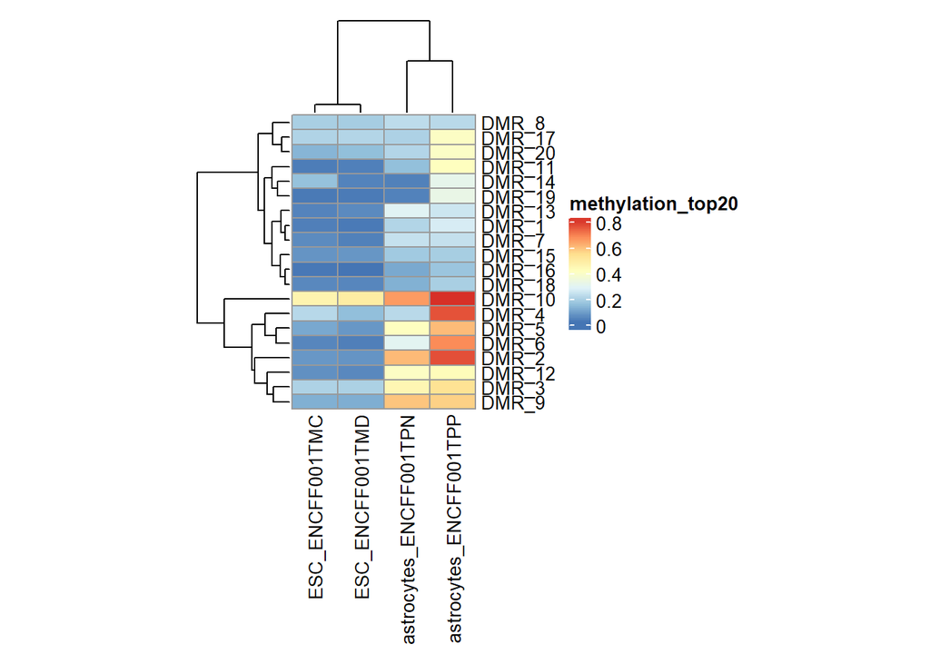

```r
pheatmap(meth_top20, name="methylation_top20", cellwidth = 25, cellheight = 8,    )
```

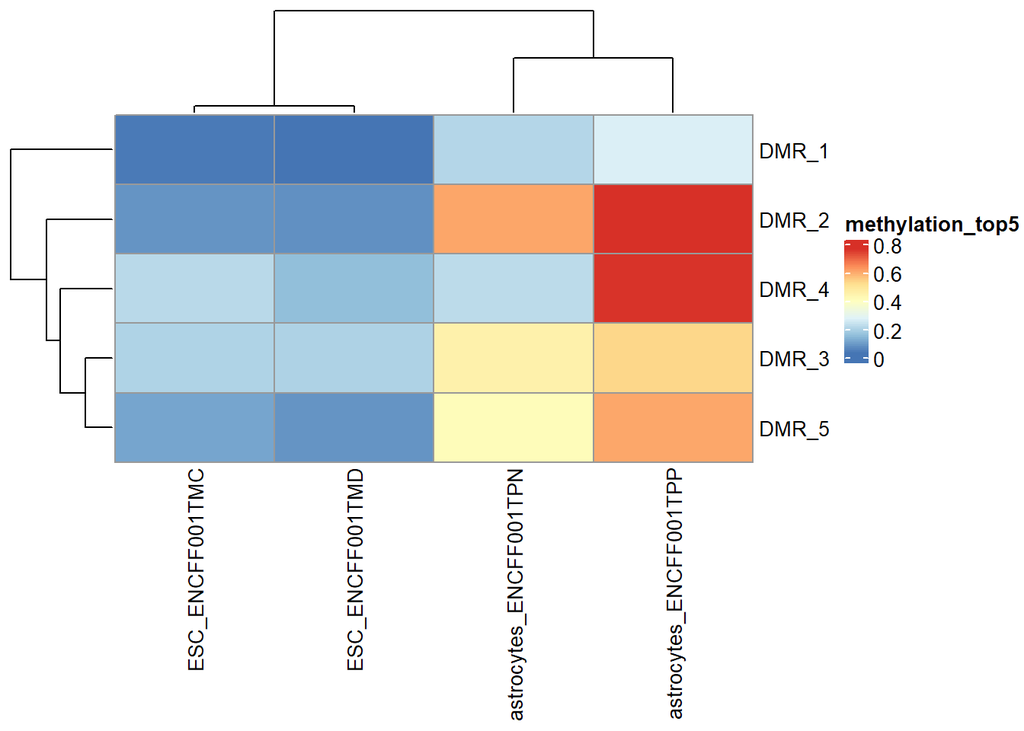

```r
pheatmap(meth_top5, name="methylation_top5")
```

## Enrichment analysis (rGREAT) of the significant DMRs from the practical vs the entire genome

```r
## 2. Enrichment Analysis of Significant DMRs

res <- great(dmrs, gene_sets = "GO:BP", tss_source = "hg19", cores = 2)
```

```
## * TSS source: TxDb.
```

```
## * check whether TxDb package 'TxDb.Hsapiens.UCSC.hg19.knownGene' is installed.
```

```
## * gene ID type in the extended TSS is 'Entrez Gene ID'.
```

```
## * restrict chromosomes to 'chr1, chr2, chr3, chr4, chr5, chr6, chr7, chr8, chr9, chr10,
##     chr11, chr12, chr13, chr14, chr15, chr16, chr17, chr18, chr19, chr20, chr21, chr22, chrX,
##     chrY, chrM'.
```

```
## * 18561/23033 protein-coding genes left.
```

```
## * update seqinfo to the selected chromosomes.
```

```
## * TSS extension mode is 'basalPlusExt'.
```

```
## * construct the basal domains by extending 5000bp to upstream and 1000bp to downsteram of TSS.
```

```
## * calculate distances to neighbour regions.
```

```
## * extend to both sides until reaching the neighbour genes or to the maximal extension.
```

```
## * use GO:BP ontology with 15413 gene sets (source: org.Hs.eg.db).
```

```
## * check gene ID type in `gene_sets` and in `extended_tss`.
```

```
## * use whole genome as background.
```

```
## * remove excluded regions from background.
```

```
## * overlap `gr` to background regions (based on midpoint).
```

```
## * in total 2797 `gr`.
```

```
## * overlap extended TSS to background regions.
```

```
## * check which genes are in the gene sets.
```

```
## * only take gene sets with size >= 5.
```

```
## * in total 9094 gene sets.
```

```
## * overlap `gr` to every extended TSS.
```

```
## * perform binomial test for each biological term.
```

```r
bp <- getEnrichmentTables(res)
head(bp)
```

```
##           id                                                description
## 1 GO:0035095                            behavioral response to nicotine
## 2 GO:0060482                                 lobar bronchus development
## 3 GO:0072044                                collecting duct development
## 4 GO:0071332                     cellular response to fructose stimulus
## 5 GO:0030812        negative regulation of nucleotide catabolic process
## 6 GO:0033122 negative regulation of purine nucleotide catabolic process
##   genome_fraction observed_region_hits fold_enrichment      p_value
## 1    0.0003218835                   20       22.214618 0.000000e+00
## 2    0.0003511700                   20       20.361985 0.000000e+00
## 3    0.0020743648                   41        7.066531 0.000000e+00
## 4    0.0002106800                   15       25.455141 2.220446e-16
## 5    0.0010493592                   26        8.858429 2.220446e-16
## 6    0.0010493592                   26        8.858429 2.220446e-16
##       p_adjust mean_tss_dist observed_gene_hits gene_set_size
## 1 0.000000e+00         76216                  4             8
## 2 0.000000e+00         74106                  3             6
## 3 0.000000e+00         91208                 11            15
## 4 1.689125e-13         80290                  3             5
## 5 1.689125e-13        131776                  5            18
## 6 1.689125e-13        131776                  5            18
##   fold_enrichment_hyper p_value_hyper p_adjust_hyper
## 1              2.965964  3.183578e-02    0.168514425
## 2              2.965964  6.411465e-02    0.245972997
## 3              4.350080  2.155427e-06    0.000110362
## 4              3.559156  3.658979e-02    0.184159375
## 5              1.647758  1.741086e-01    0.423459605
## 6              1.647758  1.741086e-01    0.423459605
```

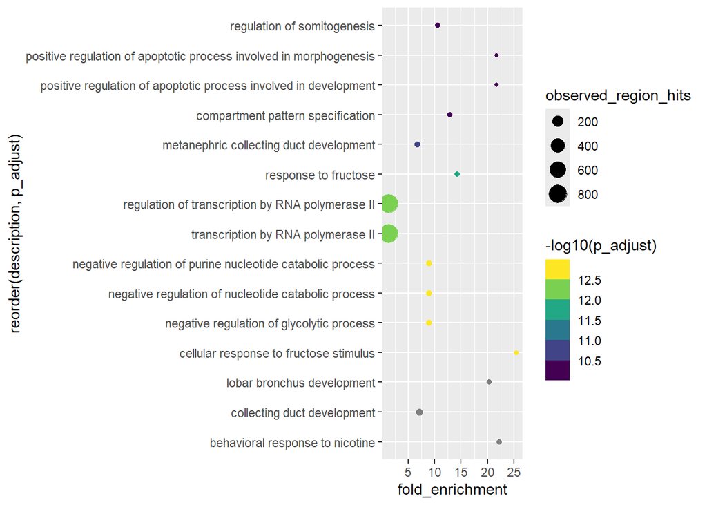

```r
ggplot(head(bp,15), aes(fold_enrichment, reorder(description, p_adjust),
                        size=observed_region_hits, color= -log10(p_adjust)))+
  geom_point()+scale_color_viridis_b()
```

This enrichment analysis compares the genes in the Differentially Methylated Regions to all the genome (that is the background in this case) based on Biological Processes from Gene Ontology.

This enrichment plot highlights the top biological processes associated with the significant DMRs. Many of the enriched termssuch as “transcription by RNA polymerase II” and “regulation of transcription” are broad and fundamental cellular processes rather than specific to cell type identity or function. This may suggest that the DMRs affect general transcriptional regulation rather than highly cell-type-specific pathways. Additionally, terms like “response to fructose” or “collecting duct development” are unexpected in the astrocyte vs. ESC context, further pointing to possible enrichment biases due to regional or chromosomal distribution of genes, rather than reflecting functional changes specific to the cell types compared.